# Data Prepration

Huizhe (Sunny) ZHU

### Step 0 - Load libraries

Install packages & Load libraries

```r
library(tm)
library(data.table)
library(tidytext)
library(tidyverse)
library(DT)
```

### Step 1 - Load the data

```r
# load lyrics data
library(readr)
raw_lyrics <- read.csv("lyrics.csv", stringsAsFactors = FALSE)
```

### Step 2 - Preliminary cleaning of text

Convert letters to the lower case, remove punctuation, numbers, empty words and extra white space.

```r
# function for removimg leading and trailing whitespace from character strings
leadingWhitespace <- content_transformer(function(x) str_trim(x, side = "both"))
# remove stop words
data("stop_words")
word <- c("lot", "today", "months", "month", "wanna", "wouldnt", "wasnt", "ha", "na", "ooh", "da",
        "gonna", "im", "dont", "aint", "wont", "yeah", "la", "oi", "nigga", "fuck",
          "hey", "year", "years", "last", "past", "feel")
stop_words <- c(stop_words$word, word)
```

```r
# clean the data and make a corpus
corpus <- VCorpus(VectorSource(raw_lyrics$lyrics))%>%
  tm_map(content_transformer(tolower))%>%
  tm_map(removePunctuation)%>%
  tm_map(removeWords, character(0))%>%
  tm_map(removeWords, stop_words)%>%
  tm_map(removeNumbers)%>%
  tm_map(stripWhitespace)%>%
  tm_map(leadingWhitespace)
```

### Step 3 - Stemming and converting to tidy object

Stemming reduces a word to its word *stem*. Each row contains 1 song - its stemmed words * Note: 11 empty lines

```r
stemmed <- tm_map(corpus, stemDocument) %>%
  tidy() %>%
  select(text)
```

### Step 4 - Tokenization on original words

*9.51* million rows (words) in total, one column

```r
dict <- tidy(corpus) %>%
  select(text) %>%
  unnest_tokens(dictionary, text)
```

### Step 5 - Tokenization on stemmed words

Add ID = row_number, dict = original word

*9.51* million rows, 3 columns

```r
completed <- stemmed %>%
  mutate(id = row_number()) %>%
  unnest_tokens(stems, text) %>%
  bind_cols(dict)
```

### Step 6 - Stem completion

Picking the original word (from the same root) with the highest frequency. The new column created - ‘word’ - will be used to replace stem, which is sometimes hard for people to understand.

```r
completed1 <- completed %>%
  group_by(stems) %>%
  count(dictionary) %>%
  mutate(word = dictionary[which.max(n)]) %>%
  ungroup() %>%
  select(stems, word) %>%
  distinct() %>%
  right_join(completed) %>%
  select(-stems)
```

### Step 7 - Pasting stem completed individual words into their respective lyrics

Put ‘word’ generated from Step 6, back to each song row - each row contains words like before - but the words are transforme, from -> stemmed -> completed stem

```r
completed2 <- completed1 %>%
  group_by(id) %>%
  summarise(stemmedwords= str_c(word, collapse = " ")) %>%
  ungroup()
```

### Step 8 - Keeping a track of the processed lyrics with their own ID

```r
raw_lyrics1 <- raw_lyrics %>%
  mutate(id = row_number()) %>%
  inner_join(completed2)
```

```r
save(raw_lyrics, file="../output/processed_lyrics2.RData")
```

The final processed data is ready to be used for any kind of analysis.

# Songs Classification - Country, Pop, Hiphop, R&B

### Step 1 - Create sub-dataset

In the dataset, there are 7534 Country songs, 18697 Pop songs, 8905 HipHops, and 2174 R&B.

```r
table(raw_lyrics1$genre)
```

```
      Country    Electronic          Folk       Hip-Hop         Indie          Jazz         Metal Not Available         Other           Pop           R&B          Rock
         7534          2812           514          8905          1318          4122         11311          3325           147         18697          2174         64845
```

```r
country = raw_lyrics1[raw_lyrics1$genre == 'Country',]
pop = raw_lyrics1[raw_lyrics1$genre == 'Pop',]
hiphop = raw_lyrics1[raw_lyrics1$genre == 'Hip-Hop',]
RB = raw_lyrics1[raw_lyrics1$genre == 'R&B',]
```

### Step 2 - Compare their lyrics length

```r
total_four_songs = bind_rows(pop,country,hiphop,RB)
total_four_songs<-total_four_songs%>%
  mutate(length=length(stemmedwords))
```

```r
mean(total_four_songs$length, na.rm=T)
```

```
[1] 37310
```

```r
tapply(X=total_four_songs$length, INDEX = total_four_songs$genre, FUN = 'mean')
```

```
Country Hip-Hop     Pop     R&B
  37310   37310   37310   37310
```

### Step 3 - Compare their high-frequency words - use it to define its topics

# 3.1 Pop

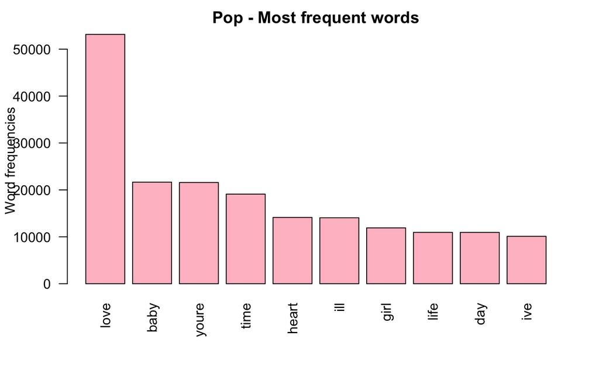

```r
tidy_pop <- unnest_tokens(pop, output = 'word', token = 'words', input = stemmedwords)%>%
  count(word,sort = TRUE)

# barplot
barplot(tidy_pop[1:10,]$n, las = 2, names.arg = tidy_pop[1:10,]$word,
        col ="pink", main ="Pop - Most frequent words",
        ylab = "Word frequencies")
```

# 3.2 Country

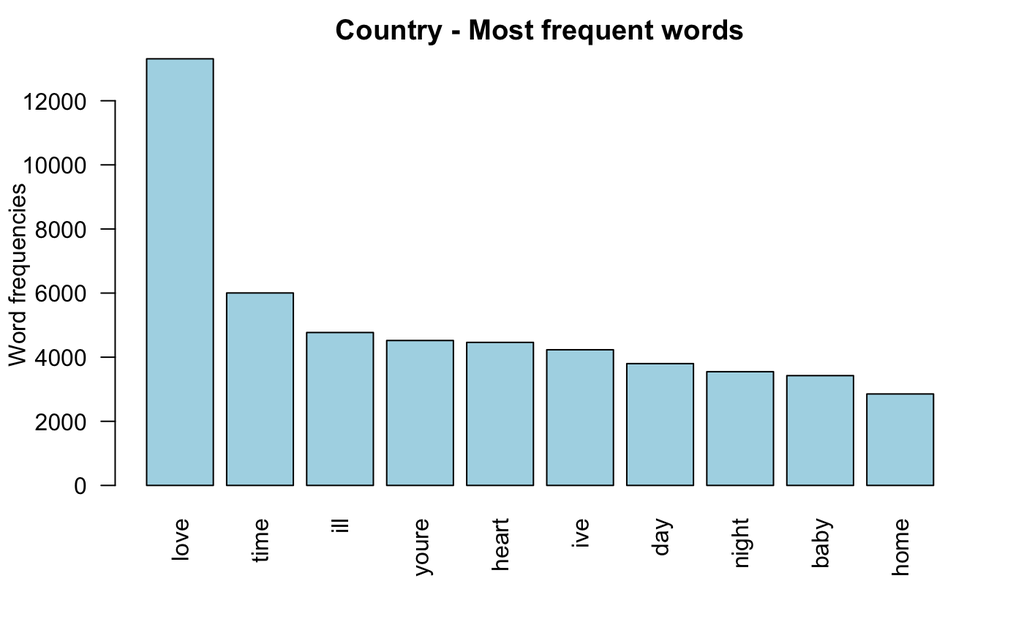

```r
tidy_country <- unnest_tokens(country, output = 'word', token = 'words', input = stemmedwords)%>%
  count(word,sort = TRUE)

# barplot
barplot(tidy_country[1:10,]$n, las = 2, names.arg = tidy_country[1:10,]$word,
        col ="light blue", main ="Country - Most frequent words",
        ylab = "Word frequencies")
```

# 3.3 HipHops

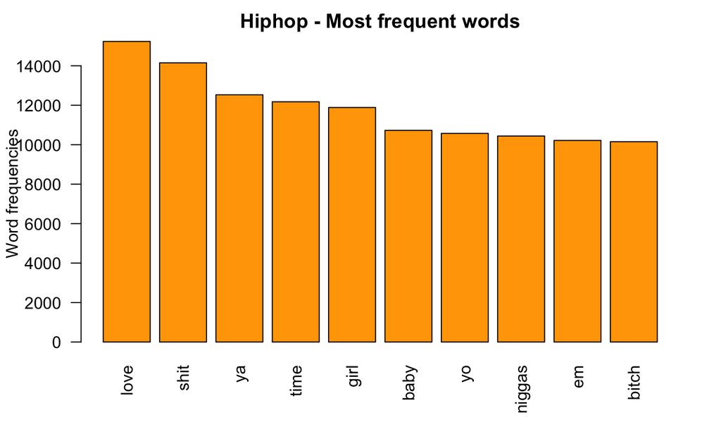

```r
tidy_hiphop <- unnest_tokens(hiphop, output = 'word', token = 'words', input = stemmedwords)%>%
  count(word,sort = TRUE)

# barplot
barplot(tidy_hiphop[1:10,]$n, las = 2, names.arg = tidy_hiphop[1:10,]$word,
        col ="orange", main ="Hiphop - Most frequent words",
        ylab = "Word frequencies")
```

# 3.4 R&B

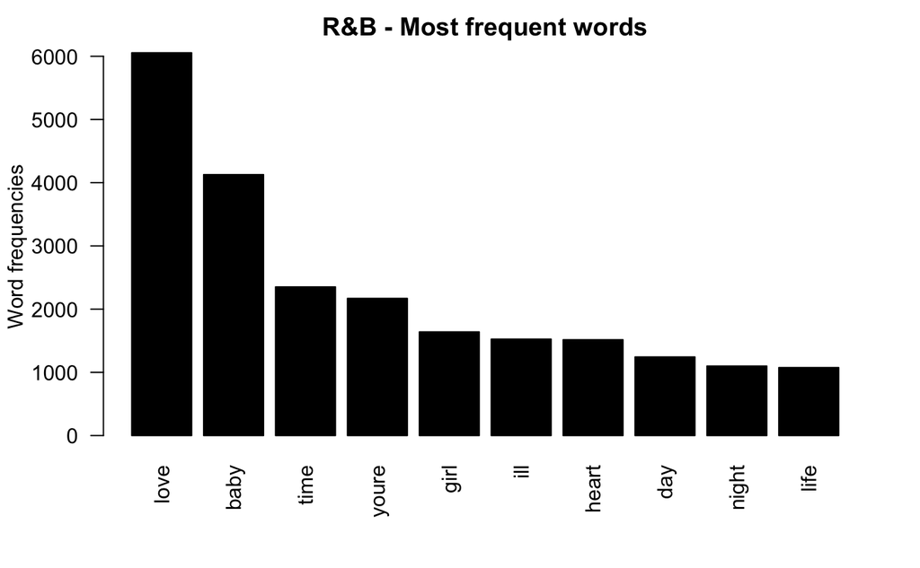

```r
tidy_RB <- unnest_tokens(RB, output = 'word', token = 'words', input = stemmedwords)%>%
  count(word,sort = TRUE)

# barplot
barplot(tidy_RB[1:10,]$n, las = 2, names.arg = tidy_RB[1:10,]$word,
        col ="black", main ="R&B - Most frequent words",
        ylab = "Word frequencies")
```

### Step 4 - Compare their emotions

Now let’s check on the sentiment!

Compare the sentiment score for these 4 different types of songs.